# Summer heat during spermatogenesis in bulls, Fig.2

Author

Jens Vanselow, Claudia Wesenauer, Anja Eggert, Arpna Sharma and Frank Becker

Published

August 30, 2023

# Libraries

```r
library(tidyverse)   # tidy world
```

```r
set.seed(1989)
```

# Station weather data

Weather data were obtained from the German Meteorological Service (Deutscher Wetterdienst, DWD). Open data of the DWD-station no. 7351 (17258 Feldberg/Mecklenburg, Germany) over the period from 2018-04-01 until 2019-03-31 were downloaded at the Climate Data Center ([DWD Open Data](https://opendata.dwd.de/climate_environment/CDC/observations_germany/)). Hourly data of 2 m air temperature (°C) and 2 m relative humidity (%) were used to calculate the hourly temperature humidity index (THI).

## Read data

```r
dwd_t2m <- read.csv2("../data/air-temperature-station.csv",
                          dec = ".", sep = ",", encoding = "UTF-8", row.names = NULL,
                          colClasses = c(Produkt_Code = "character", Zeitstempel = "character"))

dwd_rf  <- read.csv2("../data/rel-humidity-station.csv",
                          dec = ".", sep = ",", encoding = "UTF-8", row.names = NULL,
                          colClasses = c(Produkt_Code = "character", Zeitstempel = "character"))
```

## Adjust data types

As data were downloaded from German Meteorological Service (Deutscher Wetterdienst, DWD), column labels are in German.

```r
dwd_t2m <- tibble(dwd_t2m) %>%
  select(2, 3, 4) %>%
  rename(t2m = Zeitstempel,
         time = SDO_ID,
         SDO_ID = Produkt_Code) %>%
  mutate(t2m = as.numeric(t2m)) %>%
  mutate(SDO_ID = as.numeric(SDO_ID)) %>%
  mutate(time = as.POSIXct(time, format = "%Y-%m-%dT%H:%M:%S")) %>%
  drop_na(time) # for some reason there are 3 rows per station with NA in time
```

```r
dwd_rf <- tibble(dwd_rf) %>%
  select(2, 3, 4) %>%
  rename(rf = Zeitstempel,
         time = SDO_ID,
         SDO_ID = Produkt_Code) %>%
  mutate(rf = as.numeric(rf)) %>%
  mutate(SDO_ID = as.numeric(SDO_ID)) %>%
  mutate(time = as.POSIXct(time, format = "%Y-%m-%dT%H:%M:%S")) %>%
  drop_na(time) # for some reason there are 3 rows per station with NA in time
```

```r
dwd.data <- merge(dwd_t2m, dwd_rf)
dwd.data <- tibble(dwd.data) %>%
  mutate(date = as.Date(time))
```

# Calculating THI index

There are many different definitions of THI, an overview is given by Srivastava et al. (2021)

THI index of NRC (1971) is defined as:

$$THI = (1.8 \cdot T + 32) - (0.55-0.0055 \cdot RH)\cdot(1.8 \cdot T - 26)$$

THI index of Mader, Davis, and Brown-Brandl (2006) is defined as:

$$THI=0.8 \cdot T+\frac{RH}{100} \cdot(T-14.4)+46.4$$

$T$ is air temperature and given in $^{\circ} C$ and $RH$ as percentage.

Calculating THI according to NRC (1971) and Mader, Davis, and Brown-Brandl (2006):

```r
dwd.data <- dwd.data %>%
  mutate(thi.nrc = (1.8*t2m + 32) - (0.55 - 0.0055*rf)*(1.8*t2m - 26),
         thi.mad = (0.8*t2m + (rf/100)*(t2m-14.4) + 46.4))
```

- DWD und THI: [DWD-Webseite](https://www.dwd.de/DE/fachnutzer/landwirtschaft/dokumentationen/isabel/deutschland_hitzestress_bei_rinder_doku.html):

| THI_min | THI_max | Category |
| --- | --- | --- |
|  | ≤ 68 | no heat stress |
| >68 | ≤ 72 | mild heat stress |
| >72 | ≤ 80 | moderate heat stress |
| >80 | ≤ 90 | strong heat stress |
| >90 |  | extreme heat stress |

# Plot

```r
dwd.data <- dwd.data %>%
  filter(time >= ymd_hms("2018-03-31 23:00:00")) %>%
  filter(time <= ymd_hms("2019-04-01 00:00:00"))
```

```r
# english axis label
Sys.setlocale("LC_ALL", "English")
```

```
[1] "LC_COLLATE=English_United States.1252;LC_CTYPE=English_United States.1252;LC_MONETARY=English_United States.1252;LC_NUMERIC=C;LC_TIME=English_United States.1252"
```

```r
plot.thi <- dwd.data %>%
  ggplot() +
  # bull 1:  14.06.2018 until 13.08.2018
  # bull 1:  28.12.2018 until 26.02.2019
  annotate(geom = "rect",
           xmin = ymd_hms("2018-06-14 00:00:00"),
           xmax = ymd_hms("2018-08-13 23:00:00"),
           ymin = 4, ymax = 85,
           fill = "grey60", colour = NA, alpha = 0.2) +
  geom_segment(aes(x    = ymd_hms("2018-08-13 23:00:00"),
                   xend = ymd_hms("2018-08-13 23:00:00"),
                   y = 4, yend = 85),
               linetype = "dashed", linewidth = 0.4) +
  annotate(geom  = "text",
           x     = ymd_hms("2018-08-13 23:00:00"),
           y     = 4,
           label = "bull 1",
           size = 8/2.845276, angle = 90, hjust = -0.4, vjust = -0.5) +
  annotate(geom = "rect",
           xmin = ymd_hms("2018-12-28 00:00:00"),
           xmax = ymd_hms("2019-02-26 23:00:00"),
           ymin = 4, ymax = 85,
           fill = "grey60", colour = NA, alpha = 0.2) +
  geom_segment(aes(x    = ymd_hms("2019-02-26 23:00:00"),
                   xend = ymd_hms("2019-02-26 23:00:00"),
                   y = 4, yend = 85),
               linetype = "dashed", linewidth = 0.4) +
  annotate(geom  = "text",
           x     = ymd_hms("2019-02-26 23:00:00"),
           y     = 4,
           label = "bull 1",
           size = 8/2.845276, angle = 90, hjust = -0.4, vjust = -0.5) +
  # bull 2:  31.05.2018 until 30.07.2018
  # bull 2:  16.12.2018 until 14.02.2019
  annotate(geom = "rect",
           xmin = ymd_hms("2018-05-31 00:00:00"),
           xmax = ymd_hms("2018-07-30 23:00:00"),
           ymin = 3, ymax = 84,
           fill = "grey60", colour = NA, alpha = 0.2) +
  geom_segment(aes(x    = ymd_hms("2018-07-30 23:00:00"),
                   xend = ymd_hms("2018-07-30 23:00:00"),
                   y = 3, yend = 84),
               linetype = "dashed", linewidth = 0.4) +
  annotate(geom  = "text",
           x     = ymd_hms("2018-07-30 23:00:00"),
           y     = 3,
           label = "bull 2",
           size = 8/2.845276, angle = 90, hjust = -0.4, vjust = -0.5) +
  annotate(geom = "rect",
           xmin = ymd_hms("2018-12-16 00:00:00"),
           xmax = ymd_hms("2019-02-14 23:00:00"),
           ymin = 3, ymax = 84,
           fill = "grey60", colour = NA, alpha = 0.2) +
  geom_segment(aes(x    = ymd_hms("2019-02-14 23:00:00"),
                   xend = ymd_hms("2019-02-14 23:00:00"),
                   y = 3, yend = 84),
               linetype = "dashed", linewidth = 0.4) +
  annotate(geom  = "text",
           x     = ymd_hms("2019-02-14 23:00:00"),
           y     = 3,
           label = "bull 2",
           size = 8/2.845276, angle = 90, hjust = -0.4, vjust = -0.5) +
  # bull 3:  17.05.2018 until 16.07.2018
  # bull 3:  08.11.2018 until 07.01.2019
  annotate(geom = "rect",
           xmin = ymd_hms("2018-05-17 00:00:00"),
           xmax = ymd_hms("2018-07-16 23:00:00"),
           ymin = 2, ymax = 83,
           fill = "grey60", colour = NA, alpha = 0.2) +
  geom_segment(aes(x    = ymd_hms("2018-07-16 23:00:00"),
                   xend = ymd_hms("2018-07-16 23:00:00"),
                   y = 2, yend = 83),
               linetype = "dashed", linewidth = 0.4) +
  annotate(geom  = "text",
           x     = ymd_hms("2018-07-16 23:00:00"),
           y     = 2,
           label = "bull 3",
           size = 8/2.845276, angle = 90, hjust = -0.4, vjust = -0.5) +
  annotate(geom = "rect",
           xmin = ymd_hms("2018-11-08 00:00:00"),
           xmax = ymd_hms("2019-01-07 23:00:00"),
           ymin = 2, ymax = 83,
           fill = "grey60", colour = NA, alpha = 0.2) +
  geom_segment(aes(x    = ymd_hms("2019-01-07 23:00:00"),
                   xend = ymd_hms("2019-01-07 23:00:00"),
                   y = 2, yend = 83),
               linetype = "dashed", linewidth = 0.4) +
  annotate(geom  = "text",
           x     = ymd_hms("2019-01-07 23:00:00"),
           y     = 2,
           label = "bull 3",
           size = 8/2.845276, angle = 90, hjust = -0.4, vjust = -0.5) +
  # add the THI data
  geom_line(aes(x = time, y = thi.mad),
            linewidth = 0.2, col = "firebrick") +
  # add THI = 72 horizontal line
  geom_hline(yintercept = 72, linetype = "solid", linewidth = 0.4, col = "black") +
  # define axes
  scale_x_datetime(limits        = ymd_hms(c("2018-04-01 00:00:00", "2019-03-28 00:00:00")),
               date_breaks       = "1 month",
               date_minor_breaks = "1 week",
               date_labels       = "%b",
               expand            = c(0.01, 0.01)) +
  scale_y_continuous(limits = c(0, 85),
                     breaks = seq(0,85,10),
                     expand = c(0.02,0.02)) +
  # labs
  labs(x = "\n2018/2019",
       y = "Temperature Humidity Index, THI\n") +
  # theme
  my_theme +
  theme(axis.text.x = element_text(hjust = -0.3))
```

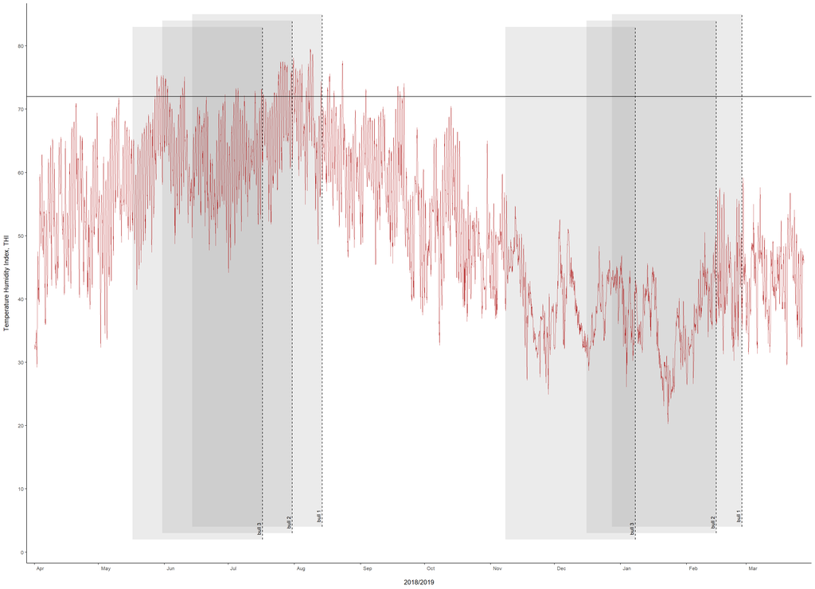

```r
png("./fig/Fig2-heat-thi.png",
    width = 165, height = 100, units = "mm",
    pointsize = 10, res = 600)

plot.thi

dev.off()
```

# How to cite R

“All analyses were performed using R Statistical Software (version 4.2.0; R Core Team 2022)”.

Reference: R Core Team (2022). R: A language and environment for statistical computing. R Foundation for Statistical Computing, Vienna, Austria. URL https://www.R-project.org/.

```r
citation()
```

```
  R Core Team (2022). R: A language and environment for statistical
  computing. R Foundation for Statistical Computing, Vienna, Austria.
  URL https://www.R-project.org/.

Ein BibTeX-Eintrag für LaTeX-Benutzer ist

  @Manual{,
    title = {R: A Language and Environment for Statistical Computing},
    author = {{R Core Team}},
    organization = {R Foundation for Statistical Computing},
    address = {Vienna, Austria},
    year = {2022},
    url = {https://www.R-project.org/},
  }

We have invested a lot of time and effort in creating R, please cite it
when using it for data analysis. See also 'citation("pkgname")' for
citing R packages.
```

```r
version$version.string
```

```
[1] "R version 4.2.0 (2022-04-22 ucrt)"
```

## References

Mader, T. L., M. S. Davis, and T. Brown-Brandl. 2006. “Environmental Factors Influencing Heat Stress in Feedlot Cattle1,2.” *Journal of Animal Science* 84 (3): 712–19. https://doi.org/10.2527/2006.843712x.

NRC, U. S. 1971. *A Guide to Environmental Research on Animals*. National Academy of Sciences, Washington, DC.

Srivastava, A., P. Yadav, A. Mahajan, M. Anand, S. Yadav, A. K. Madan, and B. Yadav. 2021. “Appropriate THI Model and Its Threshold for Goats in Semi-Arid Regions of India.” *Journal of Thermal Biology* 96 (February): 102845. https://doi.org/10.1016/j.jtherbio.2021.102845.